# MetacodeR: An R package for metabarcoding visualizations and primer evaluation

Zachary Foster and Niklaus Grunwald

May 17, 2016

## Introducing MetacodeR

Metabarcoding is revolutionizing microbial ecology and presenting new challenges:

- Numerous formats make taxonomic data difficult to parse
- The hierarchical nature of taxonmic data makes filtering and sampling complicated
- Stacked bar charts lack taxonomic context and are limited by the number of decernable colors.

MetacodeR is an R package that attempts to addresses these issues:

- Taxonomic data can be extracted from any file format definable by regular expressions.
- Data can be subset and sampled while taking into account hirearchial relationahips.
- Community diversity can be visualized by color and size in a tree-base plot.

## Parsing taxonomic data: Embedded classifications

The code below parses the Mothur 16s RDP training set.

```r
library(metacoder)
seqs <- ape::read.FASTA("trainset14_032015.rdp.fasta")
```

```r
cat(names(seqs)[1])
```

```
## AB294171_S001198039  Root;Bacteria;Firmicutes;Bacilli;Lactobacillales;Carnobacteriaceae;Alkalibacterium
```

```r
data <- extract_taxonomy(seqs[1:1000],
                         regex = "^(.*)\\t(.*)",
                         key = c(rdp_id = "obs_info", "class"),
                         class_sep = ";")
```

## Parsing taxonomic data: Embedded classifications

The resulting object looks like this when printed:

```r
data
```

```
## `taxmap` object with data for 955 taxa and 1000 observations:
##
## ---------------------------- taxa ----------------------------
## 1, 2, 3, 4, 5, 6 ... 949, 950, 951, 952, 953, 954, 955
##
## ------------------------- taxon_data -------------------------
## # A tibble: 955 × 3
##   taxon_ids supertaxon_ids              name
##       <chr>          <chr>             <chr>
## 1         1           <NA>              Root
## 2         2              1           Archaea
## 3         3              1          Bacteria
## 4         4              2   "Crenarchaeota"
## 5         5              2   "Euryarchaeota"
## 6         6              2 Nanohaloarchaeota
## 7         7              2  "Thaumarchaeota"
## # ... with 948 more rows
##
## -------------------------- obs_data --------------------------
## # A tibble: 1,000 × 3
##   obs_taxon_ids              rdp_id
##           <chr>               <chr>
## 1           458 AB294171_S001198039
## 2           171 AB243007_S000622964
## 3           830 AJ717394_S000623308
## 4           500 AJ518871_S000351779
## 5           344 CP000159_S000632736
## 6           462   X76329_S000015720
## 7           247 AB184711_S000652435
## # ... with 993 more rows, and 1 more variables: sequence <chr>
##
## ------------------------- taxon_funcs -------------------------
## n_obs, n_obs_1 ... n_subtaxa_1, hierarchies
```

## Parsing taxonomic data: Genbank accession numbers

```r
ids <- c("JQ086376.1", "AM946981.2", "JQ182735.1", "CP001396.1", "J02459.1","AC150248.3", "X64334.1", "CP001509.3", "CP006698.1", "AC198536.1","JF340119.2", "KF771025.1", "CP007136.1", "CP007133.1", "U39286.1","CP006584.1", "EU421722.1", "U03462.1", "U03459.1", "AC198467.1","V00638.1", "CP007394.1", "CP007392.1", "HG941718.1", "HG813083.1","HG813082.1", "CP007391.1", "HG813084.1", "CP002516.1", "KF561236.1","JX509734.1", "AP010953.1", "U39285.1", "M15423.1", "X98613.1","CP006784.1", "CP007393.1", "CU928163.2", "AP009240.1", "CP007025.1","CP006027.1", "CP003301.1", "CP003289.1", "CP000946.1", "CP002167.1","HG428755.1", "JQ086370.1", "CP001846.1", "CP001925.1", "X99439.1","AP010958.1", "CP001368.1", "AE014075.1", "CP002212.1", "CP003034.1","CP000243.1", "AY940193.1", "CP004009.1", "JQ182732.1", "U02453.1","AY927771.1", "BA000007.2", "CP003109.1", "CP007390.1", "U02426.1", "U02425.1", "CP006262.1", "HG738867.1", "U00096.3", "FN554766.1","CP001855.1", "L19898.1", "AE005174.2", "FJ188381.1", "AK157373.1", "JQ182733.1", "U39284.1", "U37692.1", "AF129072.1", "FM180568.1","CP001969.1", "HE616528.1", "CP002729.1", "JF974339.1", "AB248924.1", "AB248923.1", "CP002291.1", "X98409.1", "CU928161.2", "CP003297.1","FJ797950.1", "CP000038.1", "U82598.1", "CP002211.1", "JQ806764.1", "U03463.1", "CP001665.1")
contaminants <- extract_taxonomy(ids, key = c("obs_id"),
                                 database = "ncbi")
```

```r
contaminants
```

```
## `taxmap` object with data for 149 taxa and 97 observations:
##
## ---------------------------- taxa ----------------------------
## 1, 2, 3, 4, 5, 6 ... 143, 144, 145, 146, 147, 148, 149
##
## ------------------------- taxon_data -------------------------
## # A tibble: 149 × 5
##   taxon_ids supertaxon_ids                  name         rank ncbi_id
##       <chr>          <chr>                 <chr>        <chr>   <dbl>
## 1         1           <NA>    cellular organisms      no rank  131567
## 2         2           <NA>       other sequences      no rank   28384
## 3         3           <NA>               Viruses superkingdom   10239
## 4         4              1              Bacteria superkingdom       2
## 5         5              1             Eukaryota superkingdom    2759
## 6         6              4        Proteobacteria       phylum    1224
## 7         7              4 unclassified Bacteria      no rank    2323
## # ... with 142 more rows
##
## -------------------------- obs_data --------------------------
## # A tibble: 97 × 2
##   obs_taxon_ids     obs_id
##           <chr>      <chr>
## 1           148 JQ086376.1
## 2            17 AM946981.2
## 3           147 JQ182735.1
## 4            49 CP001396.1
## 5           142   J02459.1
## 6            75 AC150248.3
## 7            14   X64334.1
## # ... with 90 more rows
##
## ------------------------- taxon_funcs -------------------------
## n_obs, n_obs_1 ... n_subtaxa_1, hierarchies
```

## Parsing taxonomic data: Taxon names

Parsing bryophyte family names scraped from [The Plant List](http://www.theplantlist.org/1.1/browse/B/):

```r
taxon_names <- "http://www.theplantlist.org/1.1/browse/B/" %>%
  XML::htmlTreeParse() %>%
  XML::xmlRoot() %>%
  XML::getNodeSet("//ul[@id='nametree']/li/a/i") %>%
  sapply(XML::xmlValue)
head(taxon_names)
```

```
## [1] "Acrobolbaceae"     "Adelanthaceae"     "Allisoniaceae"
## [4] "Amblystegiaceae"   "Anastrophyllaceae" "Andreaeaceae"
```

Note that a differnt database is being used this time: The Integrated Taxonomic Information System (ITIS)

```r
bryophytes_ex_data <- extract_taxonomy(taxon_names, key = "name",
                                       database = "itis")
```

## Parsing taxonomic data: Taxon names

```r
bryophytes_ex_data
```

```
## `taxmap` object with data for 264 taxa and 171 observations:
##
## ---------------------------- taxa ----------------------------
## 1, 2, 3, 4, 5, 6 ... 258, 259, 260, 261, 262, 263, 264
##
## ------------------------- taxon_data -------------------------
## # A tibble: 264 × 5
##   taxon_ids supertaxon_ids                name    rank itis_id
##       <chr>          <chr>               <chr>   <chr>   <dbl>
## 1         1           <NA>        Calomniaceae  family   15795
## 2         2           <NA> Chaetophyllopsaceae  family   14284
## 3         3           <NA>           Chromista kingdom  630578
## 4         4           <NA>       Cyrtopodaceae  family   16526
## 5         5           <NA>       Dicnemonaceae  family   16892
## 6         6           <NA>        Ephemeraceae  family   15844
## 7         7           <NA>    Koerberiellaceae  family  190039
## # ... with 257 more rows
##
## -------------------------- obs_data --------------------------
## # A tibble: 171 × 1
##   obs_taxon_ids
##           <chr>
## 1           194
## 2           190
## 3           236
## 4            81
## 5            52
## 6            50
## 7           227
## # ... with 164 more rows
##
## ------------------------- taxon_funcs -------------------------
## n_obs, n_obs_1 ... n_subtaxa_1, hierarchies
```

## Parsing taxonomic data: Taxon IDs

Parsing included example data from the ITS1 database:

```r
file_path <- system.file("extdata", "its1_chytridiomycota_hmm.fasta",
                         package = "metacoder")
sequences <- ape::read.FASTA(file_path)
cat(names(sequences)[1])
```

```
## HQ191393_ITS1_HMM|uncultured Chytridiomycota|tax_id:175247|ITS1 located by HMM profiles,179bp length;
```

```r
its1_ex_data <- extract_taxonomy(sequences,
                                 regex = "^.*\\|(.*)\\|tax_id:(.*)\\|(.*)$",
                                 key = c(taxon_name = "taxon_info",
                                         "taxon_id", description = "obs_info"),
                                 database = "ncbi")
```

```r
its1_ex_data
```

```
## `taxmap` object with data for 110 taxa and 170 observations:
##
## ---------------------------- taxa ----------------------------
## 1, 2, 3, 4, 5, 6 ... 104, 105, 106, 107, 108, 109, 110
##
## ------------------------- taxon_data -------------------------
## # A tibble: 110 × 6
##   taxon_ids supertaxon_ids                  name         rank ncbi_id
##       <chr>          <chr>                 <chr>        <chr>   <dbl>
## 1         1           <NA>    cellular organisms      no rank  131567
## 2         2              1             Eukaryota superkingdom    2759
## 3         3              2          Opisthokonta      no rank   33154
## 4         4              3                 Fungi      kingdom    4751
## 5         5              4       Chytridiomycota       phylum    4761
## 6         6              5      Chytridiomycetes        class  451435
## 7         7              5 environmental samples      no rank  175246
## # ... with 103 more rows, and 1 more variables: taxon_name <chr>
##
## -------------------------- obs_data --------------------------
## # A tibble: 170 × 4
##   obs_taxon_ids            obs_id
##           <chr>             <chr>
## 1           100 HQ191393_ITS1_HMM
## 2           100 HQ191391_ITS1_HMM
## 3            61 KJ464412_ITS1_HMM
## 4           100 HQ191291_ITS1_HMM
## 5           100 HQ191292_ITS1_HMM
## 6           100 HQ191295_ITS1_HMM
## 7           100 HQ191296_ITS1_HMM
## # ... with 163 more rows, and 2 more variables: description <chr>,
## #   sequence <chr>
##
## ------------------------- taxon_funcs -------------------------
## n_obs, n_obs_1 ... n_subtaxa_1, hierarchies
```

## Plotting taxonomic data: Heat trees

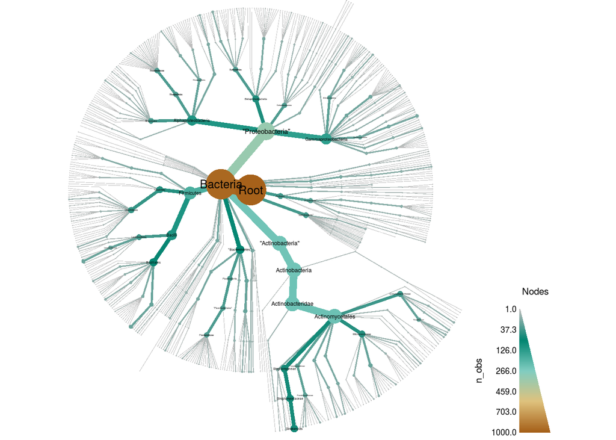

```r
heat_tree(data, node_size = n_obs,
          node_label = name, node_color = n_obs)
```

## Plotting taxonomic data: Overlap optimization

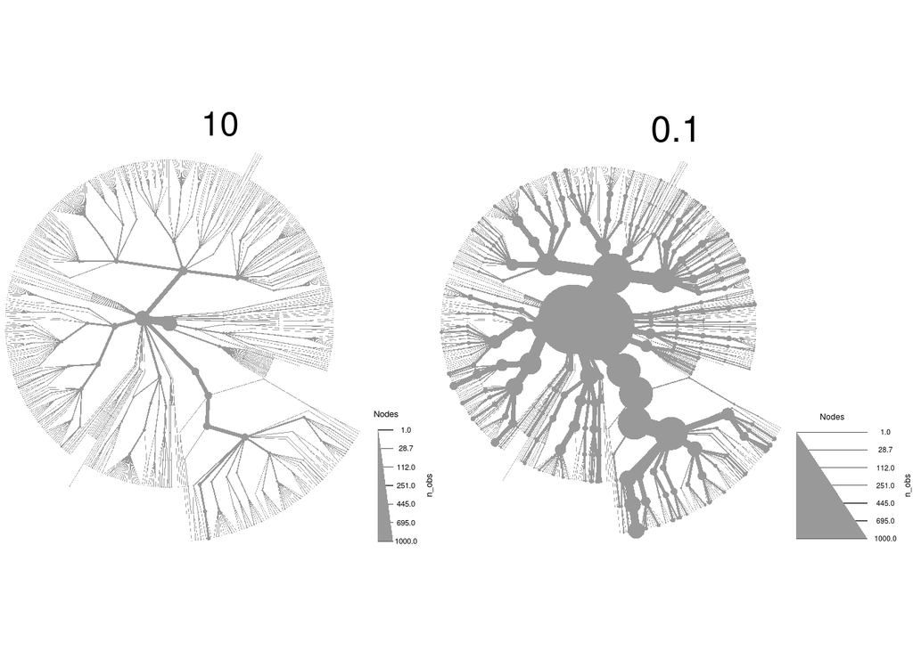

```r
heat_tree(data, node_size = n_obs, overlap_avoidance = 10, title = "10")
heat_tree(data, node_size = n_obs, overlap_avoidance = 0.1, title = "0.1")
```

## Plotting taxonomic data: Size

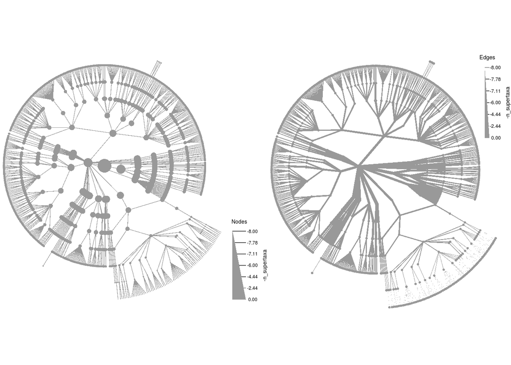

```r
heat_tree(data, node_size = - n_supertaxa, node_size_range = c(0.001, 0.03),
          edge_size_range = c(0.001, 0.001))
heat_tree(data, edge_size = - n_supertaxa, edge_size_range = c(0.0001, 0.01),
          node_size_range = c(0.005, 0.005))
```

## Plotting taxonomic data: Color

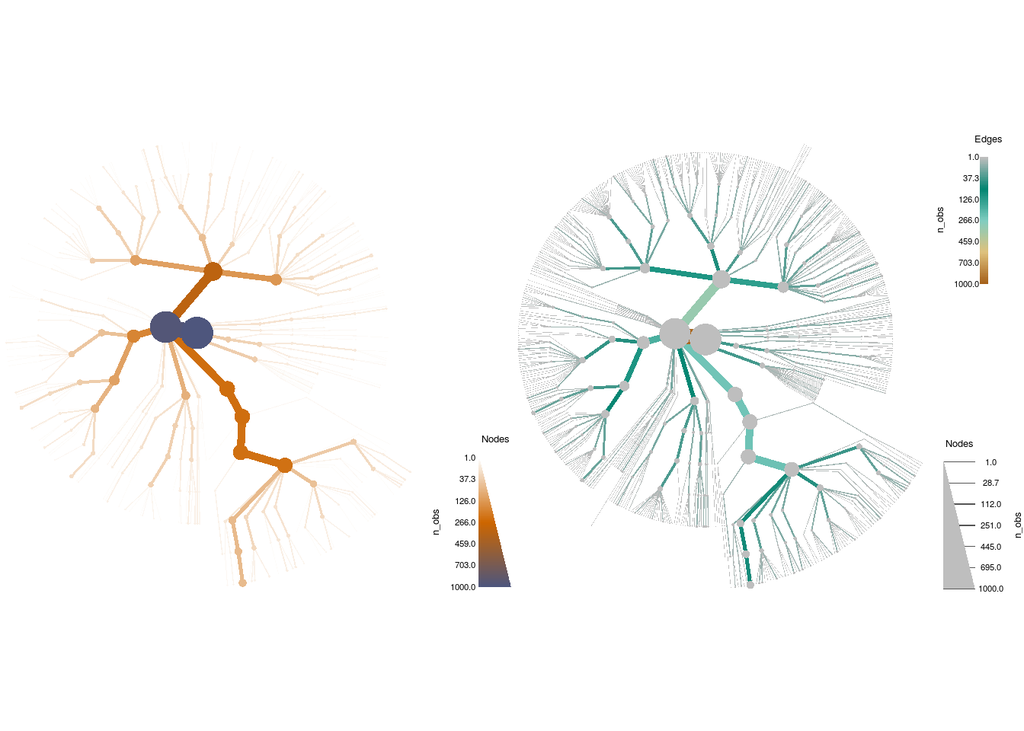

```r
heat_tree(data, node_size = n_obs, node_color = n_obs,
          node_color_range = c("#FFFFFF", "darkorange3", "#4e567d"))
heat_tree(data, node_size = n_obs, node_color = "grey",
          edge_color = n_obs)
```

## Plotting taxonomic data: Labels

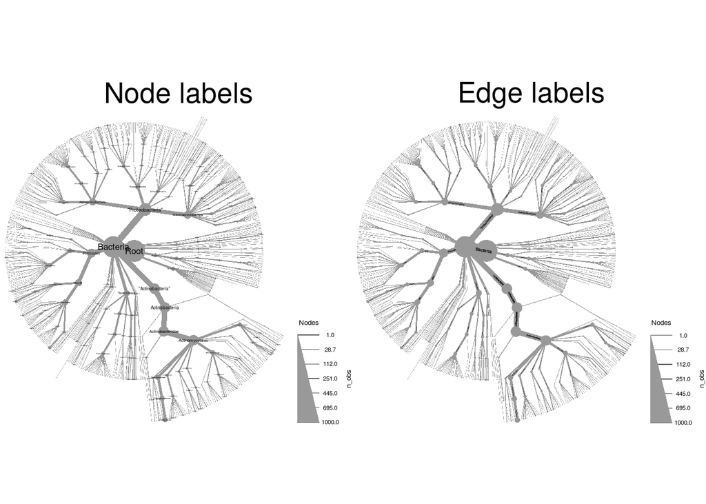

```r
heat_tree(data, node_size = n_obs, node_label = name,
          node_label_max = 200, title = "Node labels")
heat_tree(data, node_size = n_obs, edge_label = name,
          edge_label_max = 200, title = "Edge labels")
```

## Plotting taxonomic data: Layouts

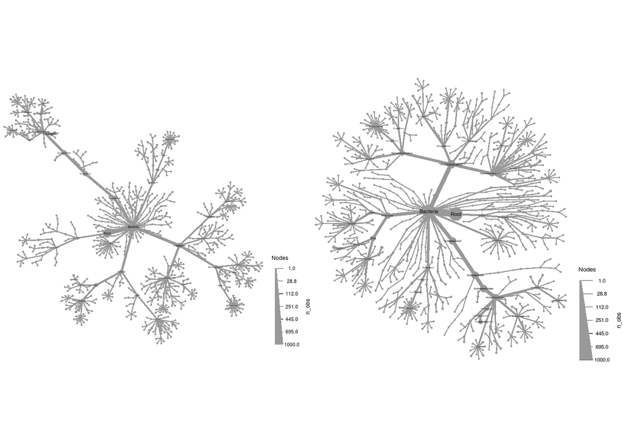

```r
set.seed(2)
heat_tree(data, node_size = n_obs, node_label = name,
          layout = "davidson-harel")
heat_tree(data, node_size = n_obs, node_label = name,
          layout = "davidson-harel", initial_layout = "reingold")
```

## Plotting taxonomic data: Multiple roots

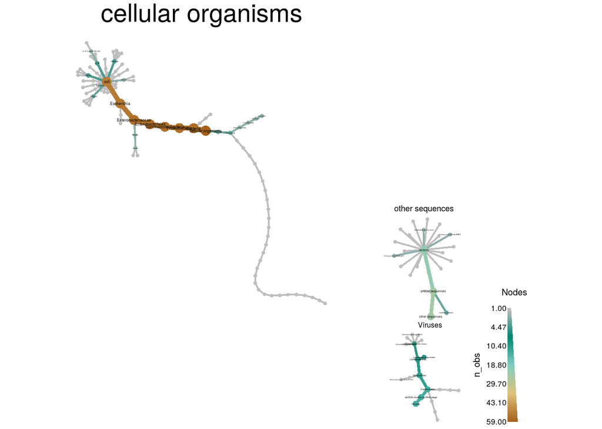

```r
set.seed(6)
heat_tree(contaminants, node_size = n_obs,
          node_color = n_obs, node_label = name,
          tree_label = name, layout = "fruchterman-reingold")
```

## Subsetting taxonomic data: Default behavior

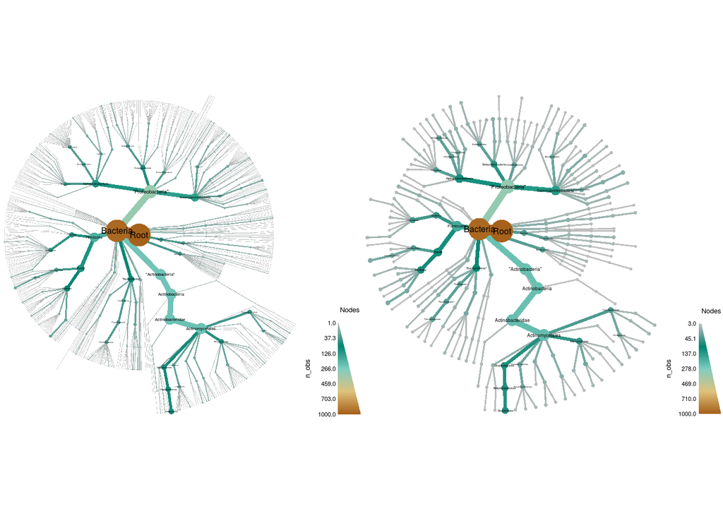

```r
data %>%
  heat_tree(node_size = n_obs, node_label = name, node_color = n_obs)
filter_taxa(data, n_obs >= 3) %>%
  heat_tree(node_size = n_obs, node_label = name, node_color = n_obs)
```

## Subsetting taxonomic data: Including subtaxa

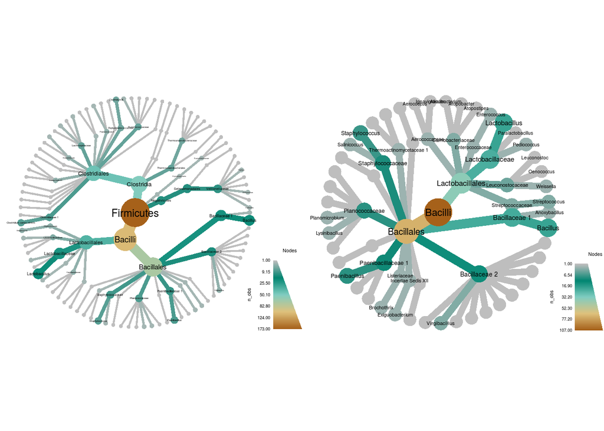

```r
filter_taxa(data, name == "Firmicutes", subtaxa = TRUE) %>%
  heat_tree(node_size = n_obs, node_label = name, node_color = n_obs)
filter_taxa(data, name == "Bacilli", subtaxa = TRUE) %>%
  heat_tree(node_size = n_obs, node_label = name, node_color = n_obs)
```

## Subsetting taxonomic data: Including supertaxa

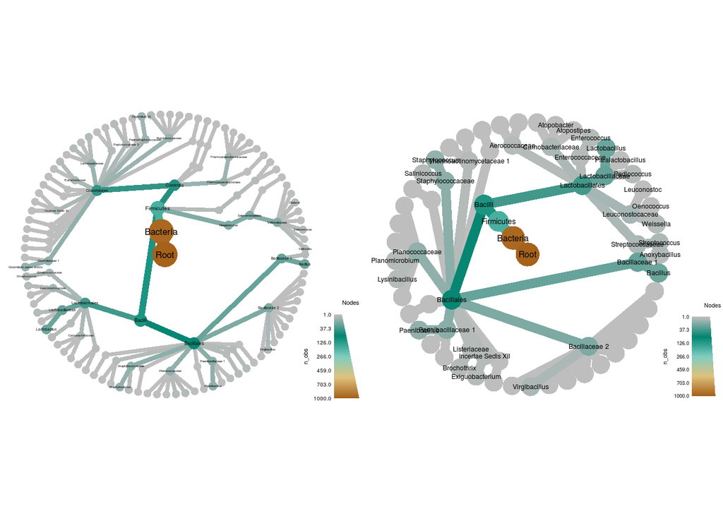

```r
filter_taxa(data, name == "Firmicutes", subtaxa = TRUE, supertaxa = TRUE) %>%
  heat_tree(node_size = n_obs, node_label = name, node_color = n_obs)
filter_taxa(data, name == "Bacilli", subtaxa = TRUE, supertaxa = TRUE) %>%
  heat_tree(node_size = n_obs, node_label = name, node_color = n_obs)
```

## Subsetting taxonomic data: Removing internal taxa

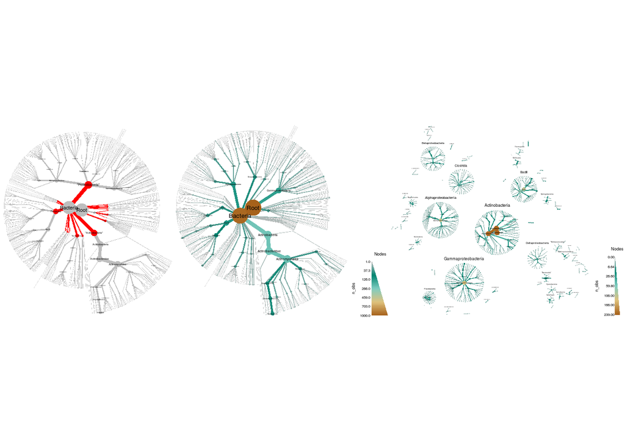

```r
data %>%
  heat_tree(node_size = n_obs, node_label = name, node_color = n_obs)
filter_taxa(data, n_supertaxa != 2) %>%
  heat_tree(node_size = n_obs, node_label = name, node_color = n_obs)
filter_taxa(data, n_supertaxa != 2, reassign_taxa = FALSE) %>%
  heat_tree(node_size = n_obs, node_label = name, node_color = n_obs, tree_label = name)
```

## Sampling taxa

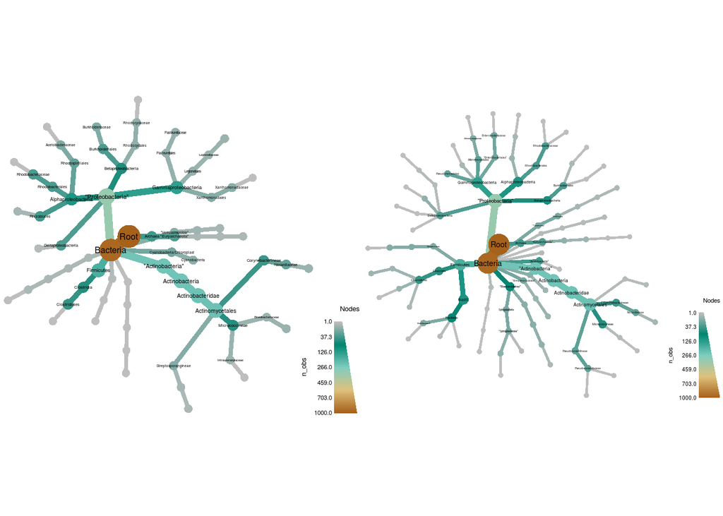

```r
set.seed(1)
sample_n_taxa(data, 20, supertaxa = TRUE) %>%
  heat_tree(node_size = n_obs, node_label = name, node_color = n_obs)
sample_n_taxa(data, 40, supertaxa = TRUE) %>%
  heat_tree(node_size = n_obs, node_label = name, node_color = n_obs)
```

## Sampling observations

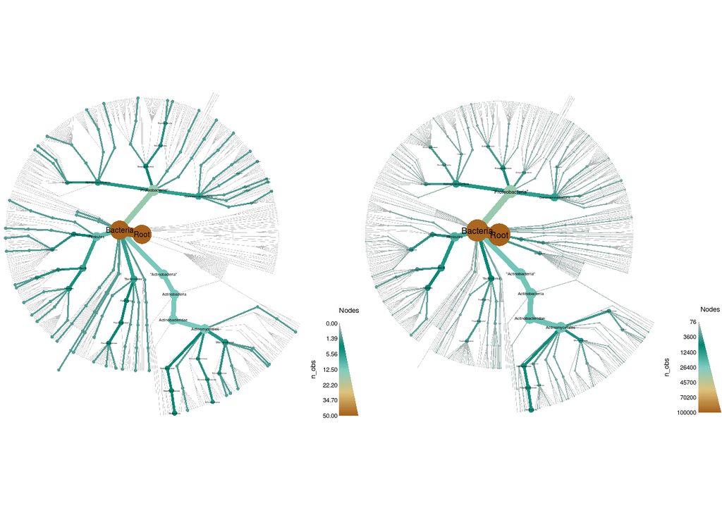

```r
sample_n_obs(data, 50) %>%
  heat_tree(node_size = n_obs, node_label = name, node_color = n_obs)
sample_n_obs(data, 100000, replace = TRUE) %>%
  heat_tree(node_size = n_obs, node_label = name, node_color = n_obs)
```

## Plans for future development

MetacodeR is under active development and many new features are planned. Some improvements that are being worked on include:

- Plotting functions for pairwise comparison of treatments
- Barcoding gap analysis and associated plotting functions
- A function to aid in retrieving appropriate sequence data from NCBI for *in silico* PCR from whole genome sequences.
- The `taxmap` class and manipulation functions are being made into an ropensci package called taxa with significant upgrades

To see the details of what is being worked on, check out the issues tab of the MetacodeR [Github site](https://github.com/grunwaldlab).